# RStudio server GIT

2023-09-20

## Adding your details to Git

In RStudio, click on terminal and enter the following, replacing the name with your GitHub username and the email address with your own.

```
git config --global user.name "Jane Doe"
git config --global user.email "jane@example.com"
```

## Creating a SSH key

In Tools > Global Options, select the Git/SVN tab.  
Confirm the “Git executable” is correct”

[figure not shown]

Click on the “Create RSA Key” button

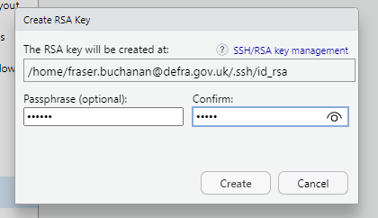

Set a Passphrase for your RSA key and click “Create”.

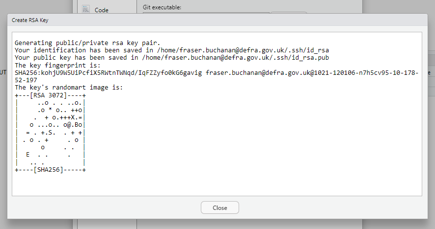

Click “Close”  
Click on the text “View public key”

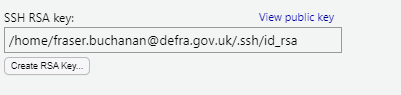

The text will be highlighted in the pop up window. Press Ctrl+c to copy the key then press “Close”.

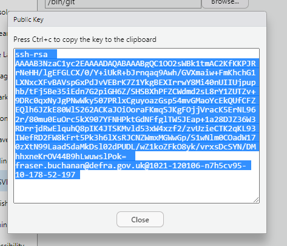

## Adding SSH key to GitHub account

Log in to your GitHub Account.  
Click on your icon on the top right hand side and select “settings”.

[figure not shown]

Click on “SSH and GPG keys” under “Access”.

[figure not shown]

Then click on the green “New SSH key” button.

[figure not shown]

Give the key a title of choice and then paste in the key, click “Add SSH key”.

[figure not shown]

If you have set up two factor authentication you may need to got through that process now. If not, please set it up.You should now see this screen and receive an email confirming the SSH is set up.

[figure not shown]

## Creating a new project with Git

File > New Project…

[figure not shown]

Select “New Directory”

[figure not shown]

Select “New Project”

[figure not shown]

Name your project directory and where it isto be located.  
Tick the “Create a git repository” box.  
Click the “Create Project” button.

## Cloning an existing project with Git

Browse to the GitHub page of the project you want to clone.  
Click on the green “<> Code” button and then the SSH tab.  
Click on the copy icon to the right of the text.

[figure not shown]

File > New Project…

[figure not shown]

Select “Version Control”

[figure not shown]

Select “Git”.

[figure not shown]

Paste the SSH URL it into the “Repository URL:” box.  
Click “Create Project”.

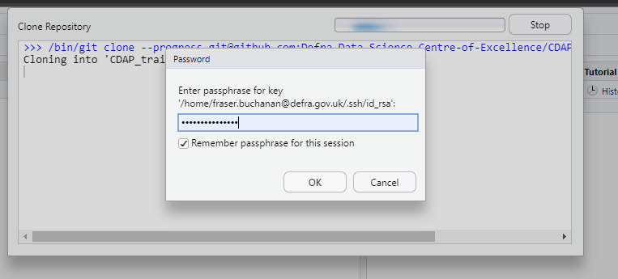

There will be popup windows asking to set up a passkey(optional), typed twice and to accept SSH key. Type “yes” and click “ok”

A window will then pop up starting the cloning process.  
A separate window will also ask for your SSH passphrase if you set one.